# Data manipulation

## Overview of the tidyverse package

Data manipulation is the core of data analysis. The **tidyverse** is an opinionated collection of R packages designed for data science. All packages share an underlying design philosophy, grammar, and data structures.

For a brief reference, see the [Cheat sheet](https://rstudio.com/wp-content/uploads/2015/02/data-wrangling-cheatsheet.pdf) and [tideverse](https://tidyverse.tidyverse.org/). For a comprehensive guide, read this book [R for Data Science] by Hadley Wickham. We will only briefly introduce some functions here and later.

Install and load the complete tidyverse:

```r
if (!require("tidyverse")) {install.packages("tidyverse")}
library("tidyverse")
```

A list of core tidyverse packages are as follows:

[figure not shown]

These packages form a pipeline of data analysis in R, working from data importing, manipulation, modelling to communicating results.

[figure not shown]

## Tidy data with tidyr

Tidy data is a way to organize tabular data. It provides a consistent data structure across packages.

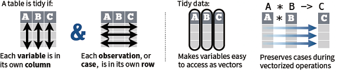

### Reshape data #### transpose

```r
# example using built-in dataset
mtcars
t(mtcars)
```

[output not shown]

#### Converting data between wide and long formats

There are two sets of methods that are explained below:  
* melt() and dcast() from the **reshape2** package.  
* gather() and spread() from the **tidyr** package. This is a newer interface to the reshape2 package. we will focus on this one.

This example is from [R cookbook](http://www.cookbook-r.com/Manipulating_data/Converting_data_between_wide_and_long_format/).

```r
olddata_wide <- read.table(header = TRUE, text = '
 subject sex control cond1 cond2
       1   M     7.9  12.3  10.7
       2   F     6.3  10.6  11.1
       3   F     9.5  13.1  13.8
       4   M    11.5  13.4  12.9
')
# Make sure the subject column is a factor
olddata_wide$subject <- factor(olddata_wide$subject)
olddata_long <- read.table(header = TRUE, text = '
 subject sex condition measurement
       1   M   control         7.9
       1   M     cond1        12.3
       1   M     cond2        10.7
       2   F   control         6.3
       2   F     cond1        10.6
       2   F     cond2        11.1
       3   F   control         9.5
       3   F     cond1        13.1
       3   F     cond2        13.8
       4   M   control        11.5
       4   M     cond1        13.4
       4   M     cond2        12.9
')
# Make sure the subject column is a factor
olddata_long$subject <- factor(olddata_long$subject)

############ From wide to long format using gather()
suppressMessages(library(tidyr))

# The arguments to gather():
# - data: Data object
# - key: Name of new key column (made from names of data columns)
# - value: Name of new value column
# - ...: Names of source columns that contain values
# - factor_key: Treat the new key column as a factor (instead of character vector)
data_long <- gather(olddata_wide, condition,
                    measurement, control:cond2, factor_key = TRUE)

#In this example, the source columns that are gathered are specified with control:cond2. This means to use all the columns, positionally, between control and cond2. Another way of doing it is to name the columns individually, as in:

gather(olddata_wide, condition, measurement, control, cond1, cond2)
```

| subject | sex | condition | measurement |
| --- | --- | --- | --- |
| 1 | M | control | 7.9 |
| 2 | F | control | 6.3 |
| 3 | F | control | 9.5 |
| 4 | M | control | 11.5 |
| 1 | M | cond1 | 12.3 |
| 2 | F | cond1 | 10.6 |
| 3 | F | cond1 | 13.1 |
| 4 | M | cond1 | 13.4 |
| 1 | M | cond2 | 10.7 |
| 2 | F | cond2 | 11.1 |

[output cut: 2 more lines]

```r
#If you need to use gather() programmatically, you may need to use variables containing column names. To do this, you should use the gather_() function instead, which takes strings instead of bare (unquoted) column names.

keycol <- "condition"
valuecol <- "measurement"
gathercols <- c("control", "cond1", "cond2")

gather_(olddata_wide, keycol, valuecol, gathercols)
```

| subject | sex | condition | measurement |
| --- | --- | --- | --- |
| 1 | M | control | 7.9 |
| 2 | F | control | 6.3 |
| 3 | F | control | 9.5 |
| 4 | M | control | 11.5 |
| 1 | M | cond1 | 12.3 |
| 2 | F | cond1 | 10.6 |
| 3 | F | cond1 | 13.1 |
| 4 | M | cond1 | 13.4 |
| 1 | M | cond2 | 10.7 |
| 2 | F | cond2 | 11.1 |

[output cut: 2 more lines]

```r
######## From long to wide use spread():
olddata_long
```

| subject | sex | condition | measurement |
| --- | --- | --- | --- |
| 1 | M | control | 7.9 |
| 1 | M | cond1 | 12.3 |
| 1 | M | cond2 | 10.7 |
| 2 | F | control | 6.3 |
| 2 | F | cond1 | 10.6 |
| 2 | F | cond2 | 11.1 |
| 3 | F | control | 9.5 |
| 3 | F | cond1 | 13.1 |
| 3 | F | cond2 | 13.8 |
| 4 | M | control | 11.5 |

[output cut: 2 more lines]

```r
# The arguments to spread():
# - data: Data object
# - key: Name of column containing the new column names
# - value: Name of column containing values
data_wide <- spread(olddata_long, condition, measurement)
data_wide
```

| subject | sex | cond1 | cond2 | control |
| --- | --- | --- | --- | --- |
| 1 | M | 12.3 | 10.7 | 7.9 |
| 2 | F | 10.6 | 11.1 | 6.3 |
| 3 | F | 13.1 | 13.8 | 9.5 |
| 4 | M | 13.4 | 12.9 | 11.5 |

### Handling missing values

1. drop_na(data, …): Drop rows containing NA’s in . columns.
2. fill(data, …, .direction = c(“down”, “up”)): Fill in NA’s in . columns with most recent non-NA values.
3. replace_na(data, replace = list(), …): Replace NA’s by column.

```r
x <- tibble(a = LETTERS[1:5], b = c(1, NA, NA, 3, NA))
drop_na(x, b)
```

| a | b |
| --- | --- |
| A | 1 |
| D | 3 |

```r
fill(x, b)
```

| a | b |
| --- | --- |
| A | 1 |
| B | 1 |
| C | 1 |
| D | 3 |
| E | 3 |

```r
replace_na(x, list(b = 2))
```

| a | b |
| --- | --- |
| A | 1 |
| B | 2 |
| C | 2 |
| D | 3 |
| E | 2 |

### Expand tables - quick create tables with combinations of values

1. complete(data, …, fill = list()): Adds to the data missing combinations of the values of the variables listed in .
2. expand(data, …) Create new tibble with all possible combinations of the values of the variables listed in .

```r
mtcars_complete <- complete(mtcars, cyl, gear, carb)

mtcars_expanded <- expand(mtcars, cyl, gear, carb)
```

### Split cells

Use these functions to split cells into individual, isolated values. 1. separate(): Separate each cell in a column to make several columns.

```r
separate(data, col, into, sep = "[^[:alnum:]]+", remove = TRUE, convert = FALSE, extra = "warn", fill = "warn", ...)
```

2. separate_rows(): Separate each cell in a column to make several rows. Also separate_rows_().

```r
separate_rows(data, ..., sep = "[^[:alnum:].]+", convert = FALSE)
```

3. unite(): Collapse cells across several columns to make a single column.

```r
unite(data, col, ..., sep = "_", remove = TRUE)
```

```r
tb <- tibble(country = rep(LETTERS[1:3], each = 2),
             year = rep(c(1999, 2000), 3),
             rate = c("0.7K/19M", "2K/20M", "37K/172M",
                      "80K/174M", "212K/1T", "213K/1T"))
# separate into wide format
tb_sep <- separate(tb, rate, into = c("case", "pop"), sep = "/")

# separate into long format
tb_sep_long <- separate_rows(tb, rate, sep = "/")

tb_back <- unite(tb_sep, case, pop, col = "rate", sep = "/")
```

## Data transformation with dplyr

In this section we mainly talk about the dplyr package for data transformation. See [the dplyr reference](https://dplyr.tidyverse.org/) and [its cheat sheet](https://github.com/rstudio/cheatsheets/blob/master/data-transformation.pdf).

```r
## Loading data
library("datasets")
library("dplyr")
# attach(iris)
str(iris)
```

```
'data.frame':   150 obs. of  5 variables:
 $ Sepal.Length: num  5.1 4.9 4.7 4.6 5 5.4 4.6 5 4.4 4.9 ...
 $ Sepal.Width : num  3.5 3 3.2 3.1 3.6 3.9 3.4 3.4 2.9 3.1 ...
 $ Petal.Length: num  1.4 1.4 1.3 1.5 1.4 1.7 1.4 1.5 1.4 1.5 ...
 $ Petal.Width : num  0.2 0.2 0.2 0.2 0.2 0.4 0.3 0.2 0.2 0.1 ...
 $ Species     : Factor w/ 3 levels "setosa","versicolor",..: 1 1 1 1 1 1 1 1 1 1 ...
```

## Introduction to the dplyr package

### Manipulate cases

#### Extract cases: using row functions to return a subset of rows as a new table

1. *filter()*: extract rows meeting logical criteria.

```r
library("dplyr")
?filter
```

```r
# Select iris data of species "virginica"
iris %>% filter(Species == "virginica")
```

| Sepal.Length | Sepal.Width | Petal.Length | Petal.Width | Species |
| --- | --- | --- | --- | --- |
| 6.3 | 3.3 | 6.0 | 2.5 | virginica |
| 5.8 | 2.7 | 5.1 | 1.9 | virginica |
| 7.1 | 3.0 | 5.9 | 2.1 | virginica |
| 6.3 | 2.9 | 5.6 | 1.8 | virginica |
| 6.5 | 3.0 | 5.8 | 2.2 | virginica |
| 7.6 | 3.0 | 6.6 | 2.1 | virginica |
| 4.9 | 2.5 | 4.5 | 1.7 | virginica |
| 7.3 | 2.9 | 6.3 | 1.8 | virginica |
| 6.7 | 2.5 | 5.8 | 1.8 | virginica |
| 7.2 | 3.6 | 6.1 | 2.5 | virginica |

[output cut: 40 more lines]

```r
# Select iris data of species and sepal length greater than 6
iris %>% filter(Species == "virginica", Sepal.Length > 6)
```

| Sepal.Length | Sepal.Width | Petal.Length | Petal.Width | Species |
| --- | --- | --- | --- | --- |
| 6.3 | 3.3 | 6.0 | 2.5 | virginica |
| 7.1 | 3.0 | 5.9 | 2.1 | virginica |
| 6.3 | 2.9 | 5.6 | 1.8 | virginica |
| 6.5 | 3.0 | 5.8 | 2.2 | virginica |
| 7.6 | 3.0 | 6.6 | 2.1 | virginica |
| 7.3 | 2.9 | 6.3 | 1.8 | virginica |
| 6.7 | 2.5 | 5.8 | 1.8 | virginica |
| 7.2 | 3.6 | 6.1 | 2.5 | virginica |
| 6.5 | 3.2 | 5.1 | 2.0 | virginica |
| 6.4 | 2.7 | 5.3 | 1.9 | virginica |

[output cut: 31 more lines]

2. *distinct()*: remove rows with duplicate values.

```r
?distinct
```

```r
distinct(iris, Species)
```

| Species |
| --- |
| setosa |
| versicolor |
| virginica |

```r
iris %>% distinct(Species, .keep_all = TRUE)
```

| Sepal.Length | Sepal.Width | Petal.Length | Petal.Width | Species |
| --- | --- | --- | --- | --- |
| 5.1 | 3.5 | 1.4 | 0.2 | setosa |
| 7.0 | 3.2 | 4.7 | 1.4 | versicolor |
| 6.3 | 3.3 | 6.0 | 2.5 | virginica |

3. *sample_frac()* and *sample_n()*: Randomly select fractions or a given number of rows

```r
sample_frac(iris, 0.5, replace = TRUE)
```

| Sepal.Length | Sepal.Width | Petal.Length | Petal.Width | Species |
| --- | --- | --- | --- | --- |
| 5.1 | 3.5 | 1.4 | 0.2 | setosa |
| 4.7 | 3.2 | 1.3 | 0.2 | setosa |
| 5.7 | 2.9 | 4.2 | 1.3 | versicolor |
| 4.4 | 3.0 | 1.3 | 0.2 | setosa |
| 6.2 | 3.4 | 5.4 | 2.3 | virginica |
| 6.7 | 3.1 | 4.4 | 1.4 | versicolor |
| 6.2 | 3.4 | 5.4 | 2.3 | virginica |
| 6.7 | 3.0 | 5.0 | 1.7 | versicolor |
| 5.5 | 2.5 | 4.0 | 1.3 | versicolor |
| 4.9 | 3.1 | 1.5 | 0.1 | setosa |

[output cut: 65 more lines]

```r
sample_n(iris, 10, replace = TRUE)
```

| Sepal.Length | Sepal.Width | Petal.Length | Petal.Width | Species |
| --- | --- | --- | --- | --- |
| 5.0 | 2.3 | 3.3 | 1.0 | versicolor |
| 5.2 | 2.7 | 3.9 | 1.4 | versicolor |
| 5.8 | 2.7 | 5.1 | 1.9 | virginica |
| 5.8 | 2.6 | 4.0 | 1.2 | versicolor |
| 5.6 | 2.9 | 3.6 | 1.3 | versicolor |
| 6.8 | 3.2 | 5.9 | 2.3 | virginica |
| 5.1 | 3.8 | 1.9 | 0.4 | setosa |
| 6.1 | 3.0 | 4.6 | 1.4 | versicolor |
| 5.8 | 2.7 | 5.1 | 1.9 | virginica |
| 5.6 | 2.7 | 4.2 | 1.3 | versicolor |

4. slice(): select rows by position; top_n(): select and order top n entries.

```r
slice(iris, 10:15)
```

| Sepal.Length | Sepal.Width | Petal.Length | Petal.Width | Species |
| --- | --- | --- | --- | --- |
| 4.9 | 3.1 | 1.5 | 0.1 | setosa |
| 5.4 | 3.7 | 1.5 | 0.2 | setosa |
| 4.8 | 3.4 | 1.6 | 0.2 | setosa |
| 4.8 | 3.0 | 1.4 | 0.1 | setosa |
| 4.3 | 3.0 | 1.1 | 0.1 | setosa |
| 5.8 | 4.0 | 1.2 | 0.2 | setosa |

```r
top_n(iris, 5, Sepal.Width)
```

| Sepal.Length | Sepal.Width | Petal.Length | Petal.Width | Species |
| --- | --- | --- | --- | --- |
| 5.4 | 3.9 | 1.7 | 0.4 | setosa |
| 5.8 | 4.0 | 1.2 | 0.2 | setosa |
| 5.7 | 4.4 | 1.5 | 0.4 | setosa |
| 5.4 | 3.9 | 1.3 | 0.4 | setosa |
| 5.2 | 4.1 | 1.5 | 0.1 | setosa |
| 5.5 | 4.2 | 1.4 | 0.2 | setosa |

#### Arrange cases

1. *arrange()*: sorts rows by values of one or multiple columns

```r
?arrange
```

```r
# Sort in ascending order of sepal length
iris %>% arrange(Sepal.Length)
```

| Sepal.Length | Sepal.Width | Petal.Length | Petal.Width | Species |
| --- | --- | --- | --- | --- |
| 4.3 | 3.0 | 1.1 | 0.1 | setosa |
| 4.4 | 2.9 | 1.4 | 0.2 | setosa |
| 4.4 | 3.0 | 1.3 | 0.2 | setosa |
| 4.4 | 3.2 | 1.3 | 0.2 | setosa |
| 4.5 | 2.3 | 1.3 | 0.3 | setosa |
| 4.6 | 3.1 | 1.5 | 0.2 | setosa |
| 4.6 | 3.4 | 1.4 | 0.3 | setosa |
| 4.6 | 3.6 | 1.0 | 0.2 | setosa |
| 4.6 | 3.2 | 1.4 | 0.2 | setosa |
| 4.7 | 3.2 | 1.3 | 0.2 | setosa |

[output cut: 140 more lines]

```r
# Sort in descending order of sepal length
iris %>% arrange(desc(Sepal.Length))
```

| Sepal.Length | Sepal.Width | Petal.Length | Petal.Width | Species |
| --- | --- | --- | --- | --- |
| 7.9 | 3.8 | 6.4 | 2.0 | virginica |
| 7.7 | 3.8 | 6.7 | 2.2 | virginica |
| 7.7 | 2.6 | 6.9 | 2.3 | virginica |
| 7.7 | 2.8 | 6.7 | 2.0 | virginica |
| 7.7 | 3.0 | 6.1 | 2.3 | virginica |
| 7.6 | 3.0 | 6.6 | 2.1 | virginica |
| 7.4 | 2.8 | 6.1 | 1.9 | virginica |
| 7.3 | 2.9 | 6.3 | 1.8 | virginica |
| 7.2 | 3.6 | 6.1 | 2.5 | virginica |
| 7.2 | 3.2 | 6.0 | 1.8 | virginica |

[output cut: 140 more lines]

```r
# combine multiple dplyr verbs in a row with the pipe operator
# Filter for species "virginica", then arrange in descending order of sepal length
iris %>%
filter(Species == "virginica") %>%
arrange(desc(Sepal.Length))
```

| Sepal.Length | Sepal.Width | Petal.Length | Petal.Width | Species |
| --- | --- | --- | --- | --- |
| 7.9 | 3.8 | 6.4 | 2.0 | virginica |
| 7.7 | 3.8 | 6.7 | 2.2 | virginica |
| 7.7 | 2.6 | 6.9 | 2.3 | virginica |
| 7.7 | 2.8 | 6.7 | 2.0 | virginica |
| 7.7 | 3.0 | 6.1 | 2.3 | virginica |
| 7.6 | 3.0 | 6.6 | 2.1 | virginica |
| 7.4 | 2.8 | 6.1 | 1.9 | virginica |
| 7.3 | 2.9 | 6.3 | 1.8 | virginica |
| 7.2 | 3.6 | 6.1 | 2.5 | virginica |
| 7.2 | 3.2 | 6.0 | 1.8 | virginica |

[output cut: 40 more lines]

#### Add cases

1. *add_row()*: add one or more rows to a table

```r
add_row(faithful, eruptions = 1, waiting = 1)
```

| eruptions | waiting |
| --- | --- |
| 3.600 | 79 |
| 1.800 | 54 |
| 3.333 | 74 |
| 2.283 | 62 |
| 4.533 | 85 |
| 2.883 | 55 |
| 4.700 | 88 |
| 3.600 | 85 |
| 1.950 | 51 |
| 4.350 | 85 |

[output cut: 263 more lines]

### Manipulate variables

#### Extract variables: Column functions return a set of columns as a new vector or table

1. pull(): Extract column values as a vector. Choose by names or index.

```r
pull(iris, Sepal.Length)
```

```
  [1] 5.1 4.9 4.7 4.6 5.0 5.4 4.6 5.0 4.4 4.9 5.4 4.8 4.8
 [14] 4.3 5.8 5.7 5.4 5.1 5.7 5.1 5.4 5.1 4.6 5.1 4.8 5.0
 [27] 5.0 5.2 5.2 4.7 4.8 5.4 5.2 5.5 4.9 5.0 5.5 4.9 4.4
 [40] 5.1 5.0 4.5 4.4 5.0 5.1 4.8 5.1 4.6 5.3 5.0 7.0 6.4
 [53] 6.9 5.5 6.5 5.7 6.3 4.9 6.6 5.2 5.0 5.9 6.0 6.1 5.6
 [66] 6.7 5.6 5.8 6.2 5.6 5.9 6.1 6.3 6.1 6.4 6.6 6.8 6.7
 [79] 6.0 5.7 5.5 5.5 5.8 6.0 5.4 6.0 6.7 6.3 5.6 5.5 5.5
 [92] 6.1 5.8 5.0 5.6 5.7 5.7 6.2 5.1 5.7 6.3 5.8 7.1 6.3
[105] 6.5 7.6 4.9 7.3 6.7 7.2 6.5 6.4 6.8 5.7 5.8 6.4 6.5
[118] 7.7 7.7 6.0 6.9 5.6 7.7 6.3 6.7 7.2 6.2 6.1 6.4 7.2
[131] 7.4 7.9 6.4 6.3 6.1 7.7 6.3 6.4 6.0 6.9 6.7 6.9 5.8
[144] 6.8 6.7 6.7 6.3 6.5 6.2 5.9
```

2. select(): Extract columns as a table. Use the helper functions with select():
- starts_with(): Starts with a prefix.
- ends_with(): Ends with a suffix.
- contains(): Contains a literal string.
- matches(): Matches a regular expression.
- num_range(): Matches a numerical range like x01, x02, x03.
- one_of(): Matches variable names in a character vector.
- everything(): Matches all variables.
- last_col(): Select last variable, possibly with an offset.

For usage, see [select helper’s documentation](https://www.rdocumentation.org/packages/dplyr/versions/0.7.2/topics/select_helpers).

```r
library("dplyr")
iris <- as_tibble(iris) # so it prints a little nicer
select(iris, Sepal.Length, Species)
```

| Sepal.Length | Species |
| --- | --- |
| 5.1 | setosa |
| 4.9 | setosa |
| 4.7 | setosa |
| 4.6 | setosa |
| 5.0 | setosa |
| 5.4 | setosa |
| 4.6 | setosa |
| 5.0 | setosa |
| 4.4 | setosa |
| 4.9 | setosa |

[output cut: 140 more lines]

```r
select(iris, starts_with("Petal"))
```

| Petal.Length | Petal.Width |
| --- | --- |
| 1.4 | 0.2 |
| 1.4 | 0.2 |
| 1.3 | 0.2 |
| 1.5 | 0.2 |
| 1.4 | 0.2 |
| 1.7 | 0.4 |
| 1.4 | 0.3 |
| 1.5 | 0.2 |
| 1.4 | 0.2 |
| 1.5 | 0.1 |

[output cut: 140 more lines]

```r
select(iris, ends_with("Width"))
```

| Sepal.Width | Petal.Width |
| --- | --- |
| 3.5 | 0.2 |
| 3.0 | 0.2 |
| 3.2 | 0.2 |
| 3.1 | 0.2 |
| 3.6 | 0.2 |
| 3.9 | 0.4 |
| 3.4 | 0.3 |
| 3.4 | 0.2 |
| 2.9 | 0.2 |
| 3.1 | 0.1 |

[output cut: 140 more lines]

```r
select(iris, contains("etal"))
```

| Petal.Length | Petal.Width |
| --- | --- |
| 1.4 | 0.2 |
| 1.4 | 0.2 |
| 1.3 | 0.2 |
| 1.5 | 0.2 |
| 1.4 | 0.2 |
| 1.7 | 0.4 |
| 1.4 | 0.3 |
| 1.5 | 0.2 |
| 1.4 | 0.2 |
| 1.5 | 0.1 |

[output cut: 140 more lines]

```r
select(iris, matches(".t."))
```

| Sepal.Length | Sepal.Width | Petal.Length | Petal.Width |
| --- | --- | --- | --- |
| 5.1 | 3.5 | 1.4 | 0.2 |
| 4.9 | 3.0 | 1.4 | 0.2 |
| 4.7 | 3.2 | 1.3 | 0.2 |
| 4.6 | 3.1 | 1.5 | 0.2 |
| 5.0 | 3.6 | 1.4 | 0.2 |
| 5.4 | 3.9 | 1.7 | 0.4 |
| 4.6 | 3.4 | 1.4 | 0.3 |
| 5.0 | 3.4 | 1.5 | 0.2 |
| 4.4 | 2.9 | 1.4 | 0.2 |
| 4.9 | 3.1 | 1.5 | 0.1 |

[output cut: 140 more lines]

```r
select(iris, Petal.Length, Petal.Width)
```

| Petal.Length | Petal.Width |
| --- | --- |
| 1.4 | 0.2 |
| 1.4 | 0.2 |
| 1.3 | 0.2 |
| 1.5 | 0.2 |
| 1.4 | 0.2 |
| 1.7 | 0.4 |
| 1.4 | 0.3 |
| 1.5 | 0.2 |
| 1.4 | 0.2 |
| 1.5 | 0.1 |

[output cut: 140 more lines]

```r
select(iris, everything())
```

| Sepal.Length | Sepal.Width | Petal.Length | Petal.Width | Species |
| --- | --- | --- | --- | --- |
| 5.1 | 3.5 | 1.4 | 0.2 | setosa |
| 4.9 | 3.0 | 1.4 | 0.2 | setosa |
| 4.7 | 3.2 | 1.3 | 0.2 | setosa |
| 4.6 | 3.1 | 1.5 | 0.2 | setosa |
| 5.0 | 3.6 | 1.4 | 0.2 | setosa |
| 5.4 | 3.9 | 1.7 | 0.4 | setosa |
| 4.6 | 3.4 | 1.4 | 0.3 | setosa |
| 5.0 | 3.4 | 1.5 | 0.2 | setosa |
| 4.4 | 2.9 | 1.4 | 0.2 | setosa |
| 4.9 | 3.1 | 1.5 | 0.1 | setosa |

[output cut: 140 more lines]

```r
vars <- c("Petal.Length", "Petal.Width")
select(iris, one_of(vars))
```

| Petal.Length | Petal.Width |
| --- | --- |
| 1.4 | 0.2 |
| 1.4 | 0.2 |
| 1.3 | 0.2 |
| 1.5 | 0.2 |
| 1.4 | 0.2 |
| 1.7 | 0.4 |
| 1.4 | 0.3 |
| 1.5 | 0.2 |
| 1.4 | 0.2 |
| 1.5 | 0.1 |

[output cut: 140 more lines]

#### Make new variables

These apply [vectorized functions](https://dplyr.tidyverse.org/reference/index.html) to columns. Vectorized funs take vectors as input and return vectors of the same length as output.

1. *mutate()*: update or create new columns of a data frame

```r
# Change Sepal.Length to be in millimeters
iris %>%
mutate(Sepal.Length = Sepal.Length*10)
```

| Sepal.Length | Sepal.Width | Petal.Length | Petal.Width | Species |
| --- | --- | --- | --- | --- |
| 51 | 3.5 | 1.4 | 0.2 | setosa |
| 49 | 3.0 | 1.4 | 0.2 | setosa |
| 47 | 3.2 | 1.3 | 0.2 | setosa |
| 46 | 3.1 | 1.5 | 0.2 | setosa |
| 50 | 3.6 | 1.4 | 0.2 | setosa |
| 54 | 3.9 | 1.7 | 0.4 | setosa |
| 46 | 3.4 | 1.4 | 0.3 | setosa |
| 50 | 3.4 | 1.5 | 0.2 | setosa |
| 44 | 2.9 | 1.4 | 0.2 | setosa |
| 49 | 3.1 | 1.5 | 0.1 | setosa |

[output cut: 140 more lines]

```r
# Create a new column called SLMm
iris %>%
mutate(SLMm = Sepal.Length*10)
```

| Sepal.Length | Sepal.Width | Petal.Length | Petal.Width | Species | SLMm |
| --- | --- | --- | --- | --- | --- |
| 5.1 | 3.5 | 1.4 | 0.2 | setosa | 51 |
| 4.9 | 3.0 | 1.4 | 0.2 | setosa | 49 |
| 4.7 | 3.2 | 1.3 | 0.2 | setosa | 47 |
| 4.6 | 3.1 | 1.5 | 0.2 | setosa | 46 |
| 5.0 | 3.6 | 1.4 | 0.2 | setosa | 50 |
| 5.4 | 3.9 | 1.7 | 0.4 | setosa | 54 |
| 4.6 | 3.4 | 1.4 | 0.3 | setosa | 46 |
| 5.0 | 3.4 | 1.5 | 0.2 | setosa | 50 |
| 4.4 | 2.9 | 1.4 | 0.2 | setosa | 44 |
| 4.9 | 3.1 | 1.5 | 0.1 | setosa | 49 |

[output cut: 140 more lines]

```r
# create a piepline
iris %>%
filter(Species=="Virginica") %>%
mutate(SLMm=Sepal.Length*10) %>%
arrange(desc(SLMm))
```

| Sepal.Length | Sepal.Width | Petal.Length | Petal.Width | Species | SLMm |
| --- | --- | --- | --- | --- | --- |

2. transmute(): Computer new columns and drop otherPkgs.

```r
transmute(mtcars, gpm = 1/mpg)
```

| gpm |
| --- |
| 0.04761905 |
| 0.04761905 |
| 0.04545455 |
| 0.04761905 |
| 0.05555556 |
| 0.05555556 |
| 0.07142857 |
| 0.04166667 |
| 0.04545455 |
| 0.05263158 |

[output cut: 22 more lines]

3. mutate_all() and mutate_if(): apply functions to every column or some columns meeting logical criteria.

```r
mutate_all(faithful, list(log, log2))
```

| eruptions | waiting | eruptions_fn1 | waiting_fn1 | eruptions_fn2 | waiting_fn2 |
| --- | --- | --- | --- | --- | --- |
| 3.600 | 79 | 1.2809338 | 4.369448 | 1.8479969 | 6.303781 |
| 1.800 | 54 | 0.5877867 | 3.988984 | 0.8479969 | 5.754888 |
| 3.333 | 74 | 1.2038728 | 4.304065 | 1.7368213 | 6.209453 |
| 2.283 | 62 | 0.8254904 | 4.127134 | 1.1909309 | 5.954196 |
| 4.533 | 85 | 1.5113840 | 4.442651 | 2.1804662 | 6.409391 |
| 2.883 | 55 | 1.0588314 | 4.007333 | 1.5275708 | 5.781360 |
| 4.700 | 88 | 1.5475625 | 4.477337 | 2.2326608 | 6.459432 |
| 3.600 | 85 | 1.2809338 | 4.442651 | 1.8479969 | 6.409391 |
| 1.950 | 51 | 0.6678294 | 3.931826 | 0.9634741 | 5.672425 |
| 4.350 | 85 | 1.4701758 | 4.442651 | 2.1210154 | 6.409391 |

[output cut: 262 more lines]

```r
mutate_if(iris, is.numeric, list(log))
```

| Sepal.Length | Sepal.Width | Petal.Length | Petal.Width | Species |
| --- | --- | --- | --- | --- |
| 1.629241 | 1.2527630 | 0.33647224 | -1.60943791 | setosa |
| 1.589235 | 1.0986123 | 0.33647224 | -1.60943791 | setosa |
| 1.547563 | 1.1631508 | 0.26236426 | -1.60943791 | setosa |
| 1.526056 | 1.1314021 | 0.40546511 | -1.60943791 | setosa |
| 1.609438 | 1.2809338 | 0.33647224 | -1.60943791 | setosa |
| 1.686399 | 1.3609766 | 0.53062825 | -0.91629073 | setosa |
| 1.526056 | 1.2237754 | 0.33647224 | -1.20397280 | setosa |
| 1.609438 | 1.2237754 | 0.40546511 | -1.60943791 | setosa |
| 1.481605 | 1.0647107 | 0.33647224 | -1.60943791 | setosa |
| 1.589235 | 1.1314021 | 0.40546511 | -2.30258509 | setosa |

[output cut: 140 more lines]

4. mutate_at(): Apply functions to specific columns.

```r
mutate_at(iris, vars(-Species), list(log))
```

| Sepal.Length | Sepal.Width | Petal.Length | Petal.Width | Species |
| --- | --- | --- | --- | --- |
| 1.629241 | 1.2527630 | 0.33647224 | -1.60943791 | setosa |
| 1.589235 | 1.0986123 | 0.33647224 | -1.60943791 | setosa |
| 1.547563 | 1.1631508 | 0.26236426 | -1.60943791 | setosa |
| 1.526056 | 1.1314021 | 0.40546511 | -1.60943791 | setosa |
| 1.609438 | 1.2809338 | 0.33647224 | -1.60943791 | setosa |
| 1.686399 | 1.3609766 | 0.53062825 | -0.91629073 | setosa |
| 1.526056 | 1.2237754 | 0.33647224 | -1.20397280 | setosa |
| 1.609438 | 1.2237754 | 0.40546511 | -1.60943791 | setosa |
| 1.481605 | 1.0647107 | 0.33647224 | -1.60943791 | setosa |
| 1.589235 | 1.1314021 | 0.40546511 | -2.30258509 | setosa |

[output cut: 140 more lines]

5. add_column(): Add new column(s).

```r
add_column(mtcars, new = 1:32)
```

|  | mpg | cyl | disp | hp | drat | wt | qsec | vs | am | gear | carb | new |
| --- | --- | --- | --- | --- | --- | --- | --- | --- | --- | --- | --- | --- |
| Mazda RX4 | 21 | 6 | 160 | 110 | 3 | 2 | 16 | 0 | 1 | 4 | 4 | 1 |
| Mazda RX4 Wag | 21 | 6 | 160 | 110 | 3 | 2 | 17 | 0 | 1 | 4 | 4 | 2 |
| Datsun 710 | 22 | 4 | 108 | 93 | 3 | 2 | 18 | 1 | 1 | 4 | 1 | 3 |
| Hornet 4 Drive | 21 | 6 | 258 | 110 | 3 | 3 | 19 | 1 | 0 | 3 | 1 | 4 |
| Hornet Sportabout | 18 | 8 | 360 | 175 | 3 | 3 | 17 | 0 | 0 | 3 | 2 | 5 |
| Valiant | 18 | 6 | 225 | 105 | 2 | 3 | 20 | 1 | 0 | 3 | 1 | 6 |
| Duster 360 | 14 | 8 | 360 | 245 | 3 | 3 | 15 | 0 | 0 | 3 | 4 | 7 |
| Merc 240D | 24 | 4 | 146 | 62 | 3 | 3 | 20 | 1 | 0 | 4 | 2 | 8 |
| Merc 230 | 22 | 4 | 140 | 95 | 3 | 3 | 22 | 1 | 0 | 4 | 2 | 9 |
| Merc 280 | 19 | 6 | 167 | 123 | 3 | 3 | 18 | 1 | 0 | 4 | 4 | 10 |

[output cut: 22 more lines]

6. rename(): Rename columns.

```r
rename(iris, Length = Sepal.Length)
```

| Length | Sepal.Width | Petal.Length | Petal.Width | Species |
| --- | --- | --- | --- | --- |
| 5.1 | 3.5 | 1.4 | 0.2 | setosa |
| 4.9 | 3.0 | 1.4 | 0.2 | setosa |
| 4.7 | 3.2 | 1.3 | 0.2 | setosa |
| 4.6 | 3.1 | 1.5 | 0.2 | setosa |
| 5.0 | 3.6 | 1.4 | 0.2 | setosa |
| 5.4 | 3.9 | 1.7 | 0.4 | setosa |
| 4.6 | 3.4 | 1.4 | 0.3 | setosa |
| 5.0 | 3.4 | 1.5 | 0.2 | setosa |
| 4.4 | 2.9 | 1.4 | 0.2 | setosa |
| 4.9 | 3.1 | 1.5 | 0.1 | setosa |

[output cut: 140 more lines]

### Summarize cases

*summarize()* or *summarise()*: Compute table of summaries for one column across all groups. variants:  
* summarize_all(): Apply funs to every columns  
* secularize_at(): Apply funs to specific columns  
* summarize_if(): Apply funs to all cols of one type

```r
# Summarize to find the median sepal length
iris %>%
summarize(medianSL = median(Sepal.Length))
```

| medianSL |
| --- |
| 5.8 |

```r
# Filter for virginica then summarize the median sepal length
iris %>%
  filter(Species == "virginica") %>%
  summarize(medianSL = median(Sepal.Length))
```

| medianSL |
| --- |
| 6.5 |

```r
# Summarize multiple varibles at once
iris %>%
  filter(Species == "virginica") %>%
  summarize(medianSL = median(Sepal.Length),
            maxSL = max(Sepal.Length))
```

| medianSL | maxSL |
| --- | --- |
| 6.5 | 7.9 |

```r
# Summarize within groups
# Find median and max sepal length of each species
iris %>%
  group_by(Species) %>%
  summarize(medianSL = median(Sepal.Length),
            maxSL = max(Sepal.Length))
```

| Species | medianSL | maxSL |
| --- | --- | --- |
| setosa | 5.0 | 5.8 |
| versicolor | 5.9 | 7.0 |
| virginica | 6.5 | 7.9 |

```r
# Find median and max petal length of each species with sepal length > 6
iris %>%
  filter(Sepal.Length > 6) %>%
  group_by(Species) %>%
  summarize(medianPL = median(Petal.Length),
            maxPL = max(Petal.Length))
```

| Species | medianPL | maxPL |
| --- | --- | --- |
| versicolor | 4.6 | 5.0 |
| virginica | 5.6 | 6.9 |

2. *count()*: Count number of rows in each group defined by the variables in …

```r
count(iris, Species)
```

| Species | n |
| --- | --- |
| setosa | 50 |
| versicolor | 50 |
| virginica | 50 |

### Group cases

Use group_by() to create a “grouped” copy of a table. dplyr functions will manipulate each “group” separately and then combine the results.

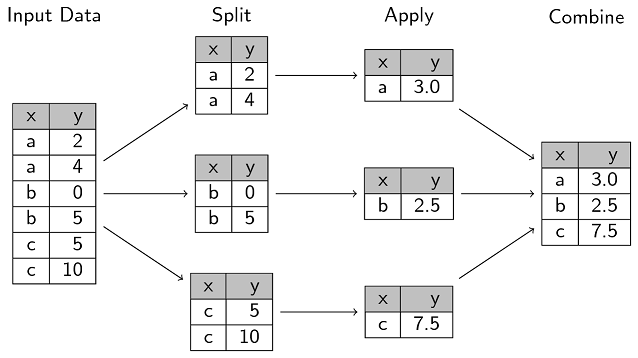

ungroup() returns ungrouped copy of table.

```r
g_iris <- group_by(iris, Species)
ungroup(g_iris)
```

| Sepal.Length | Sepal.Width | Petal.Length | Petal.Width | Species |
| --- | --- | --- | --- | --- |
| 5.1 | 3.5 | 1.4 | 0.2 | setosa |
| 4.9 | 3.0 | 1.4 | 0.2 | setosa |
| 4.7 | 3.2 | 1.3 | 0.2 | setosa |
| 4.6 | 3.1 | 1.5 | 0.2 | setosa |
| 5.0 | 3.6 | 1.4 | 0.2 | setosa |
| 5.4 | 3.9 | 1.7 | 0.4 | setosa |
| 4.6 | 3.4 | 1.4 | 0.3 | setosa |
| 5.0 | 3.4 | 1.5 | 0.2 | setosa |
| 4.4 | 2.9 | 1.4 | 0.2 | setosa |
| 4.9 | 3.1 | 1.5 | 0.1 | setosa |

[output cut: 140 more lines]

### Combining tables- Join table horizontally

#### Combine variables

1. bind_cols(): returns tables placed side by side as a single table. It works like cbind().

**Attention**: To make sense, be sure that rows align.

2. use “mutating join” to join one table to columns from another, matching values with the rows that they correspond to.

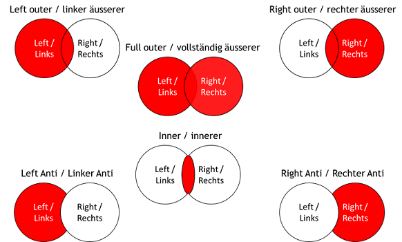

- left_join(x, y, by = NULL, copy=FALSE, suffix=c(“.x”,“.y”),.) Join matching values from y to x.
- right_join(x, y, by = NULL, copy = FALSE, suffix=c(“.x”,“.y”),.) Join matching values from x to y.
- inner_join(x, y, by = NULL, copy = FALSE, suffix=c(“.x”,“.y”),.) Join data. Retain only rows with matches.
- full_join(x, y, by = NULL, copy=FALSE, suffix=c(“.x”,“.y”),.) Join data. Retain all values, all rows.
3. Use a “Filtering Join” to filter one table against the rows of another.
- semi_join(x, y, by = NULL, .) Return rows of x that have a match in y. USEFUL TO SEE WHAT WILL BE JOINED.
- anti_join(x, y, by = NULL, .) Return rows of x that do not have a match in y. USEFUL TO SEE WHAT WILL NOT BE JOINED.

How to set the argument *by*:

- Use by = c(“col1”, “col2”, .) to specify one or more common columns to match on. left_join(x, y, by = “A”)
- Use a named vector, by = c(“col1” = “col2”), to match on columns that have different names in each table. left_join(x, y, by = c(“C” = “D”))
- Use suffix to specify the suffix to give to unmatched columns that have the same name in both tables. left_join(x, y, by = c(“C” = “D”), suffix = c(“1”, “2”))

Taking the band membership dataset for example to demonstrate different ways of joining. These datasets (band_instruments, band_instruments2, and band_members) describe band members of the Beatles and Rolling Stones. They are toy data sets that can be displayed in their entirety on a slide (e.g. to demonstrate a join).

```r
# To load the data,
library(dplyr)
data(package = "dplyr")
```

```r
# take a look at the data
View(band_instruments)
View(band_instruments2)
View(band_members)

# "Mutating" joins combine variables from the LHS and RHS
band_members %>% inner_join(band_instruments)
```

| name | band | plays |
| --- | --- | --- |
| John | Beatles | guitar |
| Paul | Beatles | bass |

```r
band_members %>% left_join(band_instruments)
```

| name | band | plays |
| --- | --- | --- |
| Mick | Stones | NA |
| John | Beatles | guitar |
| Paul | Beatles | bass |

```r
band_members %>% right_join(band_instruments)
```

| name | band | plays |
| --- | --- | --- |
| John | Beatles | guitar |
| Paul | Beatles | bass |
| Keith | NA | guitar |

```r
band_members %>% full_join(band_instruments)
```

| name | band | plays |
| --- | --- | --- |
| Mick | Stones | NA |
| John | Beatles | guitar |
| Paul | Beatles | bass |
| Keith | NA | guitar |

```r
# "Filtering" joins keep cases from the LHS
band_members %>% semi_join(band_instruments)
```

| name | band |
| --- | --- |
| John | Beatles |
| Paul | Beatles |

```r
band_members %>% anti_join(band_instruments)
```

| name | band |
| --- | --- |
| Mick | Stones |

```r
# "Nesting" joins keep cases from the LHS and nests the RHS
band_members %>% nest_join(band_instruments)
```

|  | name | band | band_instruments |
| --- | --- | --- | --- |
| 1 | Mick | Stones |  |
| 2 | John | Beatles |  |
| 3 | Paul | Beatles |  |

```r
# To suppress the message, supply by
band_members %>% inner_join(band_instruments, by = "name")
```

| name | band | plays |
| --- | --- | --- |
| John | Beatles | guitar |
| Paul | Beatles | bass |

```r
# Use a named `by` if the join variables have different names
band_members %>% full_join(band_instruments2, by = c("name" = "artist"))
```

| name | band | plays |
| --- | --- | --- |
| Mick | Stones | NA |
| John | Beatles | guitar |
| Paul | Beatles | bass |
| Keith | NA | guitar |

## Type conversion between data structures

Use *is.foo* to test for data type foo. Returns TRUE or FALSE Use *as.foo* to explicitly convert it.

is.numeric(), is.logical(), is.character(), is.vector(), is.atomic(), is.list(), is.factor(), is.matrix(), is.data.frame()

as.numeric(), as.logical(), as.character(), as.vector(), as.list(), as.factor(), as.matrix(), as.data.frame)

**Attention**: When is the is.vector() test valid? Remember how to convert factor to numeric vector sensibly?

|  | to one long vector | to matrix | to data frame | to tibble |
| --- | --- | --- | --- | --- |
| from vector | c(x,y) | cbind(x,y); rbind(x,y) | data.frame(x,y) | tibble(x, y) |
| from matrix | as.vector(mymatrix) |  | as.data.frame(mymatrix) | as_tibble(mymatrix) |
| from data frame |  | as.matrix(myframe) |  | as_tibble(myframe) |
| from tibble |  |  | as.data.frame(mytibble) |  |

## Manipulation on other types of data

Use the **forcats** package to manipulate [factor vectors](https://forcats.tidyverse.org/); use the **lubridate** package to manipulate [date and time data](https://lubridate.tidyverse.org/).

## Advanced topic

Apply functions with purr on [lists](https://purrr.tidyverse.org/).

## Exercise

Here we will use the chick weight data to practice data manipulation uisng dplyr.

```r
# -----------------------------------------------
# Examples of using dplyr on the ChickWeight data
# ------------------------------------------------

library(tidyverse)         # Load tidyverse

chick <- as_tibble(ChickWeight)   # Save a copy of the ChickWeight data as chick

# Change some column names with rename()

chick <- chick %>%
  rename(arm = Diet,         # New = arm, old = Diet
         weight_g = weight)  # new = weight_g, old = weight

# Select rows with filter()

chick %>%
  filter(weight_g > 40 & arm == 1)   # Only rows where weight_g > 40 and arm == 1
```

| weight_g | Time | Chick | arm |
| --- | --- | --- | --- |
| 42 | 0 | 1 | 1 |
| 51 | 2 | 1 | 1 |
| 59 | 4 | 1 | 1 |
| 64 | 6 | 1 | 1 |
| 76 | 8 | 1 | 1 |
| 93 | 10 | 1 | 1 |
| 106 | 12 | 1 | 1 |
| 125 | 14 | 1 | 1 |
| 149 | 16 | 1 | 1 |
| 171 | 18 | 1 | 1 |

[output cut: 206 more lines]

```r
# Add columns with mutate()

chick <- chick %>%
  mutate(
    weight_g_kg = weight_g / 1000,  # Add new column of weight_g in kilograms
    time_week = Time / 7        # Add time_week as time in weeks
  )

# Sort rows with arrange()

chick <- chick %>%
  arrange(arm, weight_g)   # sort rows by arm and then weight_g

# Recode variables with case_when()

chick <- chick %>%
  mutate(
    arm_name = case_when(      # Rename arms with strings
      arm == 1 ~ "vegetables",
      arm == 2 ~ "fruit",
      arm == 3 ~ "candy",
      arm == 4 ~ "meat"

    )
  )

# Grouped statistics with group_by() and summarise()

chick %>%                             # Start with chick data...
  group_by(arm) %>%                   # Group by arm...
  summarise(                          # Summarise the following
    weight_g_mean = mean(weight_g),   # Mean weight
    weight_g_max = max(weight_g),     # Max weight
    time_mean = mean(Time),           # Mean time
    N = n()) %>%                      # Number of cases...
  arrange(weight_g_mean)              # Sort by mean weight
```

| arm | weight_g_mean | weight_g_max | time_mean | N |
| --- | --- | --- | --- | --- |
| 1 | 102.6455 | 305 | 10.48182 | 220 |
| 2 | 122.6167 | 331 | 10.91667 | 120 |
| 4 | 135.2627 | 322 | 10.75424 | 118 |
| 3 | 142.9500 | 373 | 10.91667 | 120 |

```r
# Many sequential functions

chick %>%
  rename(weeks = Time) %>%            # Change column name
  filter(Chick > 10) %>%              # Only chicks with values larger than 10
  group_by(weeks, arm) %>%             # Group by Time and arm
  summarise(                          # Calculate summary statistics
    weight_g_median = median(weight_g),
    weight_g_sd = sd(weight_g),
    N = n()                           # Counts of cases
  )
```

| weeks | arm | weight_g_median | weight_g_sd | N |
| --- | --- | --- | --- | --- |
| 0 | 1 | 42.0 | 0.9473309 | 13 |
| 0 | 2 | 40.5 | 1.4944341 | 10 |
| 0 | 3 | 41.0 | 1.0327956 | 10 |
| 0 | 4 | 41.0 | 1.0540926 | 10 |
| 2 | 1 | 49.0 | 3.5787836 | 13 |
| 2 | 2 | 48.5 | 2.8751812 | 10 |
| 2 | 3 | 49.5 | 2.4129281 | 10 |
| 2 | 4 | 51.5 | 1.9321836 | 10 |
| 4 | 1 | 58.0 | 3.9451366 | 13 |
| 4 | 2 | 59.0 | 2.2997584 | 10 |

[output cut: 38 more lines]